# L8 - Hierarchical & Web Data

## Lecture Goals

- Understand hierarchical/tree data
  - Read data in XML format
- Scrape data from the web
  - Read data from HTML documents
- Readings
  - [XML Basics](https://www.w3schools.com/xml/default.asp)
  - [Data Scraping example in R](http://thatdatatho.com/2018/11/01/web-scraping-indeed-jobs-r-rvest/)

## Hierarchical Data

- Data with *tree-like* structure
  - Collection of *nested* nodes containing information and/or other nodes
  - E.g Company's organizational structure

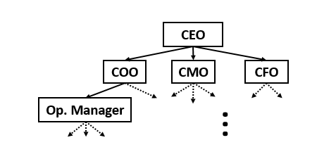

## Markup Languages

- Hierarchical info can be described with *markup languages*
  - Most general is **XML** (Extensible Markup Language)
  - Others include *HTLM* (Hyper-Text Markup Language), *Mardkdown* and *Latex*
- Sample XML

  ```
  <CEO >
    <COO>
      <Op_Manager> ... </Op_Manager>
    </COO>
    <CMO> ... </CMO>
    <CFO> ... </CFO>
  </CEO>
  ```

## XML Basics

- XML documents consist of *nested elements*, some with *attributes*
  - Elements demarcated by `<element_name> ... </element_name>`
  - Attributes given by *key-value pairs* `<person gender="female">`
  - Element content can be data or other elements

    ```
    <?xml version="1.0" encoding="UTF-8"?>
    <bookstore>
      <book category="cooking">
    <title lang="en">Everyday Italian</title>
    <author>Giada De Laurentiis</author>
    <year>2005</year>
    <price>30.00</price>
      </book>
      ...
    </bookstore>
    ```

## XML TREE

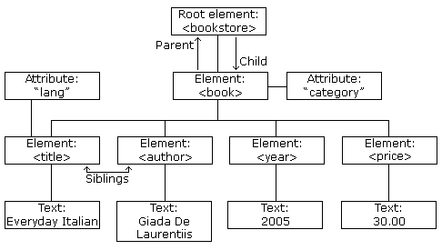

(https://www.w3schools.com/xml/xml_syntax.asp)

## XML in R

- `xml2` package for working with XML data

```r
library(xml2)
bookstore = read_xml("./data/bookstore.xml")
class( bookstore )
## [1] "xml_document" "xml_node"
bookstore
## {xml_document}
## <bookstore>
## [1] <book category="cooking">\n  <title lang="en">Everyday Italian</titl ...
## [2] <book category="children">\n  <title lang="en">Harry Potter</title>\ ...
## [3] <book category="web">\n  <title lang="en">XQuery Kick Start</title>\ ...
## [4] <book category="web" cover="paperback">\n  <title lang="en">Learning ...
```

## XPath

- XPath uses path-like *expressions* to access *nodes* (elements or attributes) in an XML document

| expression | selects |
| --- | --- |
| `/bookstore` | root *bookstore* element |
| `//book` | all *book* elements, anywhere in document |
| `/bookstore/book[last()-1]` | next-to-last *book* element |
| `//@lang` | all *lang* attributes |
| `/*[@*]` | any element with any attribute |
| `//title[@lang='en']` | all *title* elements with attribute *lang*='en' |

(https://www.w3schools.com/xml/xpath_syntax.asp)

## `xml2` Functions

- `xml_structure()` shows structure of XML doc
- `xml_find_first/all("XPath")` finds first/all nodes described by XPath expression
- `xml_attr()` retrieves node attribute
- `xml_text()` retrieve node content as text

## Example

```r
bookstore %>%
  xml_find_all( "//book[price<40]/author") %>%
  xml_text()
## [1] "Giada De Laurentiis" "J K. Rowling"        "Erik T. Ray"

bookstore %>%
  xml_find_all( "//book[@category='web']/title") %>%
  xml_attr("lang")
## [1] "en" "en"
```

## Web Data

- Ways to extract information from the web
  - Dedicated interface
  - Scraping webpages

[figure not shown]

## Web Scrapping

- All webpages expressed as HTML documents
  - Browsers interpret HTML and present content
  - Similar to XML, and can be parsed the same way

```
<!DOCTYPE html>
<html>
<head>
  <title>STAA57 - Hierarchical & Web Data</title>
  <meta charset="utf-8">
  <meta http-equiv="Content-Type" content="text/html; charset=utf-8" />
...
```

## Example

- Search workopolis.ca for *Data Science* jobs *in Toronto* https://www.workopolis.com/jobsearch/find-jobs?ak=data+scientist&l=Toronto%2C+ON

[figure not shown]

## Web Scrapping in R

- `rvest` package offers similar functionality to `xml2` for HTML
- Common workflow
  - Read document tree with `read_html()`
  - Select nodes with `html_nodes()`
  - Extract info with `html_text/attr()`

## Example

```r
library(rvest)
URL = "https://www.workopolis.com/jobsearch/find-jobs?ak=data+scientist&l=Toronto%2C+ON"
read_html(URL) %>%
  html_nodes(xpath = "//*[@class='JobCard-title']") %>%
  html_attr("title") %>% head()
```

```
## [1] "Data Scientist - AI/ML"
## [2] "Data Scientist"
## [3] "Data Team Lead"
## [4] "Data Scientist, for Advanced Analytics with Big Data"
## [5] "Research Scientist, Google AI"
## [6] "Research Scientist, Google Brain"
```

## Navigating HTML

- *View source* or *inspect elements* of webpage in your browser
  - Available in Firefox/Chrome/Edge/Safari

[figure not shown]

## CSS Selectors

- HTML documents have standard elements & structure
- *CSS selectors* are easier way to navigate them

| expression | selects |
| --- | --- |
| `body` | all <body> elements |
| `.title` | all elements with *class = 'title'* |
| `#fname` | all elements with *id = 'fname'* |
| `[title]` | all elements with title attribute |

(https://www.w3schools.com/csSref/css_selectors.asp)

## Example

- Same as before, using CSS selector

```r
read_html(URL) %>%
  html_nodes(css = ".JobCard-title") %>%
  html_attr("title") %>% head()
## [1] "Data Scientist - AI/ML"
## [2] "Data Scientist"
## [3] "Data Team Lead"
## [4] "Data Scientist, for Advanced Analytics with Big Data"
## [5] "Research Scientist, Google AI"
## [6] "Research Scientist, Google Brain"
```